```python
%run ~/Repo/Training/notebooks/GenerateTestData.ipynb
```

# Analytical Thinking and Interpretation Test

Welcome to the Analytical Thinking and Interpretation in Data Science Test! This assessment is designed to gauge your critical thinking, interpretative skills, and creativity in using data to solve real-world problems. Throughout this test, you'll encounter a variety of questions that will challenge you to think beyond just data and algorithms and consider the implications and applications of data science in practical scenarios.

## Instructions

- **Duration**: The test has no time limit. Make sure you are able to focus and go thru the questions with patience. This test is about analytical skills, not speed.
- **Responses**: Provide your answers concisely and clearly in the space provided. Make sure to justify your reasoning for each answer.
- **Resources**: This test is open-book, meaning you can use any available resources such as textbooks, notes, and internet articles
- **Question Types**: You'll encounter a mix of short answer and discussion questions. Some questions will present you with plots, tables, or scenarios related to data science, machine learning models, natural language processing, and more. This test will not evaluate your coding ability, but your analytical and problem solving skills.

Before you begin, ensure that you are comfortable interpreting visual data representations like histograms, bar charts, and scatter plots. Good luck!

## u.AI - powered by WONDER DATALABS

[figure not shown]

## Question 1: Uncovering Sensor Issues Through Descriptive Statistics

Below is the output from the `.describe()` method applied to a DataFrame containing time series data from various sensors. One of the sensor's data has shown signs of abnormality. Analyze the descriptive statistics presented and identify any potential issues. Discuss your findings and speculate on what might be the underlying problem with the data.

```python
df2.describe()
```

|  | Engine Speed | Turbo A Inlet Temp | Turbo A Outlet Temp | Turbo B Inlet Temp | Turbo B Outlet Temp | Turbo A Speed | Turbo B Speed | Fuel Inlet Temp | Fuel Rack Position | Engine Load Percent | Fuel Inlet Pressure |
| --- | --- | --- | --- | --- | --- | --- | --- | --- | --- | --- | --- |
| count | 2727.000000 | 2.727000e+03 | 2727.000000 | 2727.000000 | 2727.000000 | 2727.000000 | 2727.000000 | 2727.000000 | 2727.000000 | 2727.000000 | 2727.000000 |
| mean | 719.593663 | 5.780000e+01 | 446.131991 | 489.534300 | 418.217488 | 14735.752234 | 14672.589901 | 35.380991 | 28.116286 | 0.338882 | 8.112017 |
| std | 0.725495 | 1.563481e-13 | 11.628495 | 15.669301 | 12.081087 | 1523.529526 | 1517.744082 | 0.614004 | 3.567035 | 0.052861 | 0.211707 |
| min | 714.000000 | 5.780000e+01 | 406.875000 | 440.000000 | 376.714286 | 10375.000000 | 10705.000000 | 33.590000 | 16.600000 | 0.190561 | 7.380000 |
| 25% | 719.375000 | 5.780000e+01 | 436.000000 | 477.142857 | 407.500000 | 13665.227273 | 13607.803030 | 35.094999 | 25.572500 | 0.301182 | 7.986515 |
| 50% | 719.500000 | 5.780000e+01 | 446.166667 | 489.833333 | 418.111111 | 14569.000000 | 14508.333333 | 35.545000 | 27.672727 | 0.332860 | 8.054445 |
| 75% | 719.809091 | 5.780000e+01 | 457.200000 | 503.375000 | 429.500000 | 15616.083333 | 15570.000000 | 35.795000 | 30.224039 | 0.369318 | 8.144808 |
| max | 727.000000 | 5.780000e+01 | 465.909091 | 522.000000 | 439.000000 | 20414.166667 | 20418.333333 | 36.590000 | 43.590909 | 0.594889 | 9.437000 |

```python
#Answer Here
```

## Question 2: Setting Thresholds for Diesel Engine Status

You are given a histogram plot representing the distribution of several variables from measurements taken from a diesel engine. Your task is to determine a threshold that could be used to classify whether the engine is running or not. Based on the data distribution for each variable, propose which variable and corresponding threshold value should be used to make this determination.

Examine the histogram closely and consider the following in your rationale:

- Which variable provides the clearest separation between running and non-running states of the engine?
- Is there a specific point in the distribution that could serve as an optimal threshold to decide the engine status?
- Discuss how certainty and uncertainty factor into your decision for selecting a threshold.

**Response:**

*Please write your answer below, explaining which variable you would select and the value you would choose as the threshold. Justify your choice with logical reasoning based on the information presented in the histogram.*

```
<function matplotlib.pyplot.show(close=None, block=None)>
```

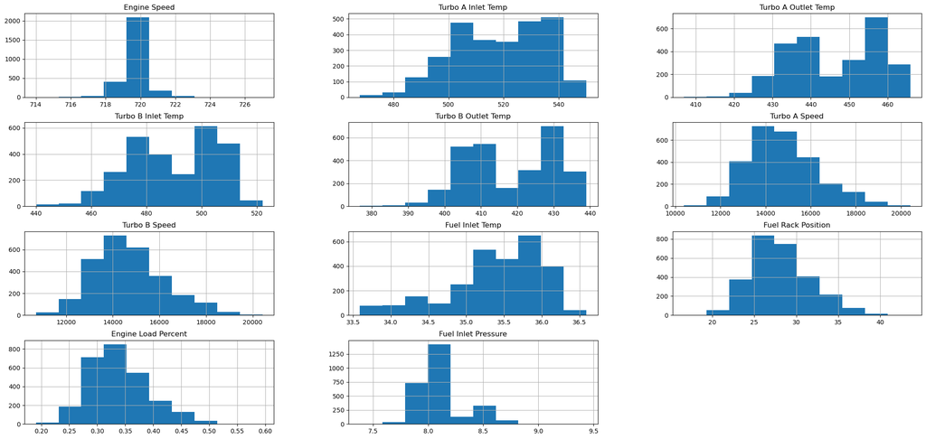

```python
df.hist(figsize=(26, 12))
plt.show
```

```python
#Answer Here
```

## Question 3: Variable Selection for Predictive Modeling

In this question, you are presented with a seaborn pairplot showing relationships between all the variables collected from a diesel engine. Based on the visual patterns and relationships depicted in the pairplot, determine which variables you would select to create a predictive model for 'Turbo A Speed' and explain your reasoning.

Consider the following aspects in your analysis:

- Look for patterns, trends, or clear relationships between 'Turbo A Speed' and other variables.
- Assess the usefulness of each variable in predicting 'Turbo A Speed' based on the strength and type of correlation observed.
- Discuss any potential issues with multicollinearity or variables that do not show any apparent relationship.
- Explain how the chosen variables might contribute to the predictive accuracy of your model.

**Response:**

*Write your analysis here, specifying which variables you would include in your model to predict 'Turbo A Speed'. Provide a rationale for your choices, referring explicitly to the patterns or correlations that you observe in the pairplot.*

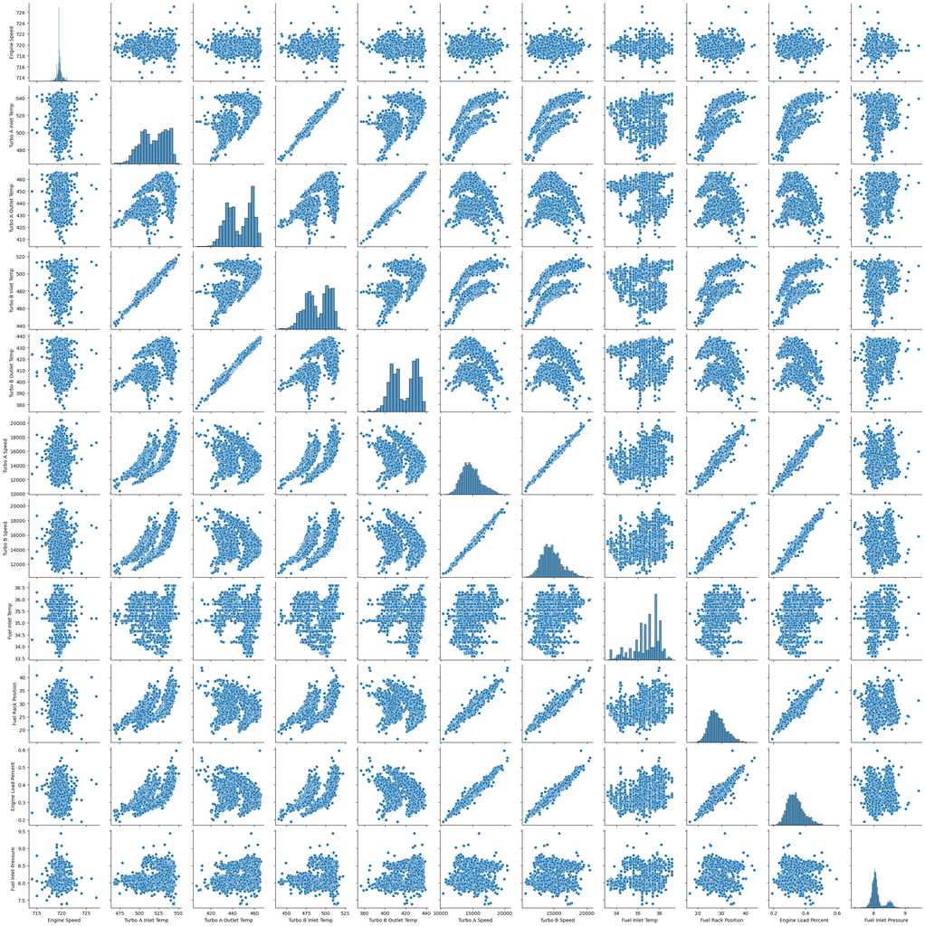

```python
# Scatter plot matrix for 'Turbo A Speed' versus all the other variables:
sns.pairplot(df)
plt.show()
```

```python
#Answer Here
```

## Question 4: Conceptualizing a Virtual Sensor for Diesel Consumption

Given the seaborn pairplot from the previous question, imagine a scenario where a sensor for measuring diesel consumption is unavailable. You are tasked with the challenge of creating a "virtual sensor" that can estimate diesel consumption by leveraging correlations with other known sensors.

Your response should address the following points:

- Based on the relationships observed among the variables, which sensors would you select to correlate with diesel consumption, and why?
- Describe how the chosen variables could be used together to act as proxies for direct measurements of fuel usage.
- Discuss any considerations regarding the accuracy and reliability of your virtual sensor, and how you might validate or improve it.

**Response:**

*In the space below, articulate your approach to designing a virtual sensor for diesel consumption. Select variables that you believe could serve as reasonable estimators for this measurement, and explain the logic behind your choices and how they might be combined to infer fuel consumption.*

```python
#Answer Here
```

## Question 5: Developing a KPI for Fuel Burn Efficiency

From the data provided, and building upon the insights from the seaborn pairplot in the previous question, you are now required to develop a Key Performance Indicator (KPI) that measures the efficiency of fuel burn in the engine.

Your response should address the following points:

- Define a suitable KPI for measuring fuel efficiency in diesel engines, and provide a rationale for your choice.
- Identify which variables from the dataset could be used to calculate this KPI, and justify how these variables are relevant to fuel efficiency.
- Propose a method for calculating your chosen KPI, including any formulas or algorithms that you would use.
- Discuss the potential challenges you may encounter when measuring and interpreting this KPI, and suggest how these challenges might be overcome.

**Response:**

In the space below, describe your approach to defining and calculating a KPI for fuel burn efficiency. Explain your choice for the KPI, the rationale behind selecting specific variables, your proposed calculation method, and address any possible challenges in measurement and interpretation.

```python
#Answer Here
```

## Question 6: Analysis of a Bimodal Histogram

Examine the histogram provided below, which represents a bimodal distribution of a dataset:

[figure not shown]

Answer the following questions:

1. Describe the key characteristics of a bimodal distribution as evident in the histogram.
2. What implications can you draw about the dataset from the bimodal nature of the distribution?
3. Provide real-world examples where bimodal distributions are commonly encountered.

**Response:**

*In the space below, comment on the histogram provided. Explain what a bimodal distribution signifies, the insights it provides about the dataset, and give examples of such distributions in real-world scenarios.*

```python
#Answer Here
```

## Question 7: Interpretation of Skewness in Distributions

The plot below shows a histogram of a skewed distribution (specifically, a log-normal distribution) with the median and mean indicated by vertical lines—the mean is marked by a red dashed line, and the median is marked by a green solid line.

[figure not shown]

**Given Data:**

- Mean: approximately 1.68
- Median: approximately 1.03

Examine the characteristics of the distribution and consider the given data points:

1. Explain why in this distribution the mean is greater than the median, and what this indicates about the skewness of the distribution.
2. Discuss the impact of skewness on the mean and median, and why they differ in this scenario.
3. Provide real-world examples where the mean is influenced by extreme values (outliers), such as income distribution where a few very high incomes raise the mean significantly above the median.
4. Analyze the appropriateness of using the mean or the median in different situations and consider when it would be more informative or fair to use the median instead of the mean due to the presence of outliers.

**Response:**

*In the space below, provide your interpretation of the histogram. Discuss the significance of the mean being greater than the median, the effect of skewness on these measures of central tendency, and offer real-world examples where such a distribution may arise. Also, evaluate when it might be more appropriate to use the median instead of the mean for analysis.*

```python
#Answer Here
```

## Question 8: Evaluating a Classification Model

In this question, you are presented with two plots related to the performance of a classification model: a Confusion Matrix and an ROC Curve.

The Confusion Matrix on the left visualizes the true positives (TP), false positives (FP), false negatives (FN), and true negatives (TN) predictions made by the model. This tool helps assess the model's performance, highlighting potential biases when dealing with imbalanced classes.

The ROC Curve on the right displays the trade-off between the true positive rate and false positive rate across different thresholds. The Area Under the Curve (AUC) quantifies the model's ability to differentiate between classes, with 1 representing perfect prediction and 0.5 reflecting no predictive power at all.

[figure not shown]

Examine the plots and answer the following questions:

1. How would you interpret the performance of this model based on the confusion matrix provided?
2. Is this model more prone to false positives or false negatives, and what implications does this have?
3. Based on the ROC curve and the AUC value, how well does this model distinguish between the classes?
4. Can you infer any reasons for the model's performance from these plots? Could the model be overfitting, and if so, what indicators lead you to that conclusion?

**Response:**

*In the space below, analyze the classification model’s performance. Discuss your interpretation of the confusion matrix, the balance between false positives and false negatives, the implications of the ROC curve and AUC value, and potential indicators of overfitting or other issues.*

```python
#Answer Here
```

## Question 9: Analytical Thinking in NLP and LLM through Word Embeddings

Below is a plot depicting word embeddings, where words are clustered based on their similarity in a multidimensional space. The plot is designed to visualize how an NLP model groups words based on their meanings and associations.

[figure not shown]

Consider the arrangement and clustering of words in the plot, and answer the following questions:

1. Why might certain words be grouped together in the plot? What does this tell us about their relationship in the context of the model's understanding?
2. What does the distance between clusters suggest about the relationships between categories of words?
3. How could the arrangement of words in this plot be useful for tasks like semantic search or automated categorization?
4. What might this plot fail to capture about language, and how could that impact real-world applications of such embeddings?

**Response:**

*In the space below, analyze the embedding plot and its implications. Discuss the rationale behind word groupings, the significance of cluster distances, applications, and limitations of such visualizations in understanding language.*

```python
#Answer Here
```

## Question 10: Interpreting Sentiment Analysis Results

The bar chart below represents hypothetical sentiment scores for a set of five customer reviews. The scores range from very positive to very negative, illustrating the sentiment analysis output for each review.

[figure not shown]

Examine the bar chart and consider the following questions:

1. Based on the sentiment scores presented in the bar chart, which reviews would you prioritize for action, and why?
2. How might these sentiment scores inform a business strategy for product improvement or customer service enhancements?
3. Discuss the potential pitfalls of relying solely on sentiment scores from this analysis for decision-making.
4. Considering the language used in customer reviews, evaluate any potential inaccuracies in the sentiment analysis. For example, could the use of sarcasm, humor, or idiomatic expressions lead to incorrect sentiment scores?

**Response:**

*In the space below, provide your interpretations of the sentiment analysis bar chart. Explain which reviews would require immediate action and discuss the use of sentiment analysis in shaping business strategies. Address the limitations of such analysis and potential inaccuracies due to the nuances of language usage.*

```python
#Answer Here
```

## Test Closing Message

Thank you for completing the analytical assessment presented by **Wonder DataLabs** and our research division, **u.AI**. We hope you found this exercise thought-provoking and insightful.

Please remember that in the realm of data science and artificial intelligence, there are often no absolute right or wrong answers. What is most important is your thought process, creativity, and analytical ability to approach complex problems. Your effort and dedication in participating in this exercise is a testament to your commitment to the field and contributes to the ongoing evolution of AI.

**Wonder DataLabs**, along with everyone at **u.AI**, values your contribution and enthusiasm for advancing the future of AI development. We look upon the paths you will carve with anticipation and excitement.

We wish you the best of luck in all your future endeavors and hope to see you at the forefront of AI innovation.